# Fundamentos análisis de datos - Práctica final

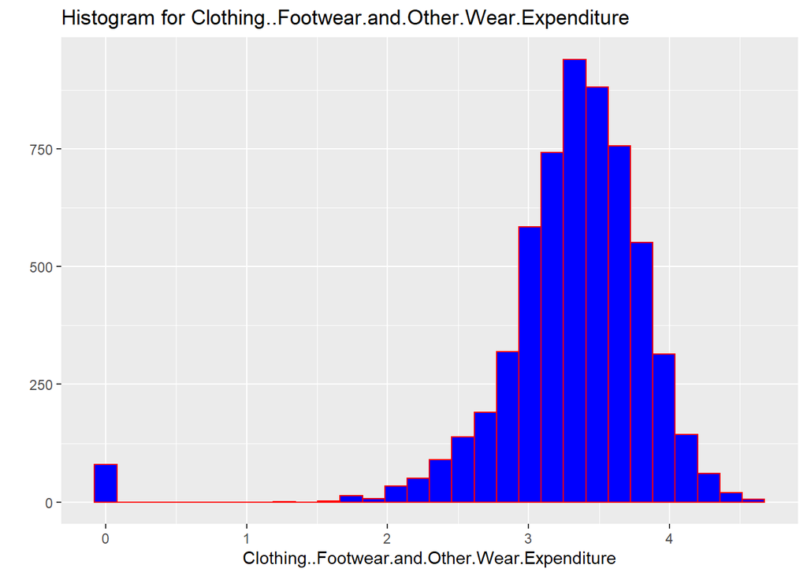

```r
qplot(Log_sin_inf[1:7000,12],
      geom="histogram",
      main = "Histogram for Clothing..Footwear.and.Other.Wear.Expenditure",
      xlab = "Clothing..Footwear.and.Other.Wear.Expenditure",
      fill=I("blue"),
      col=I("red"))
```

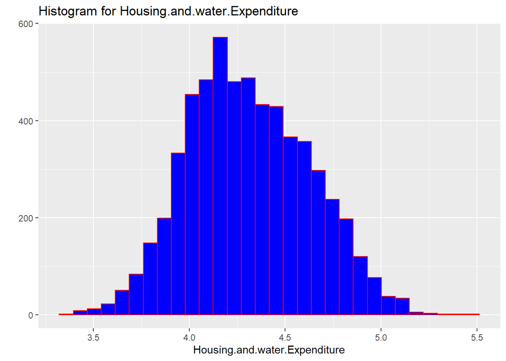

```r
qplot(Log_sin_inf[1:7000,13],
      geom="histogram",
      main = "Histogram for Housing.and.water.Expenditure",
      xlab = "Housing.and.water.Expenditure",
      fill=I("blue"),
      col=I("red"))
```

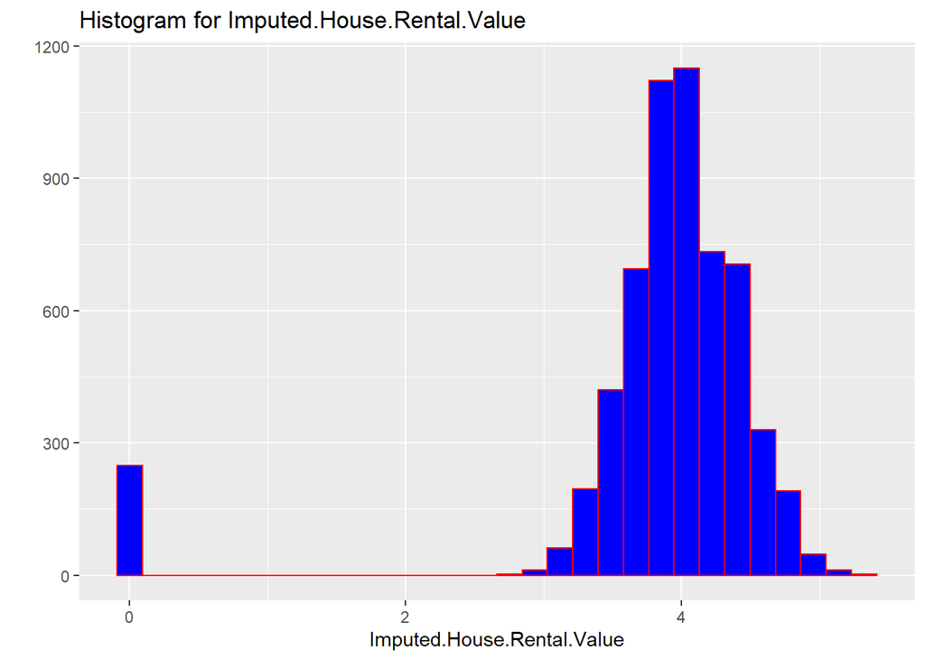

```r
qplot(Log_sin_inf[1:7000,14],
      geom="histogram",
      main = "Histogram for Imputed.House.Rental.Value",
      xlab = "Imputed.House.Rental.Value",
      fill=I("blue"),
      col=I("red"))
```

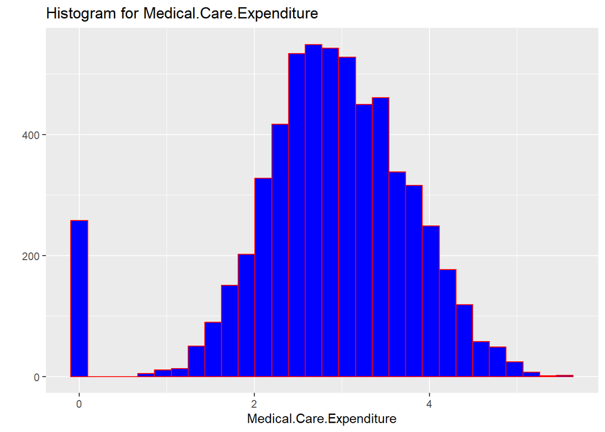

```r
qplot(Log_sin_inf[1:7000,15],
      geom="histogram",
      main = "Histogram for Medical.Care.Expenditure",
      xlab = "Medical.Care.Expenditure",
      fill=I("blue"),
      col=I("red"))
```

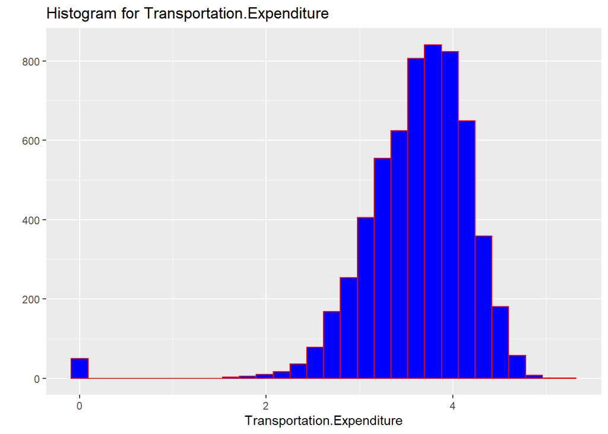

```r
qplot(Log_sin_inf[1:7000,16],
      geom="histogram",
      main = "Histogram for Transportation.Expenditure",
      xlab = "Transportation.Expenditure",
      fill=I("blue"),
      col=I("red"))
```

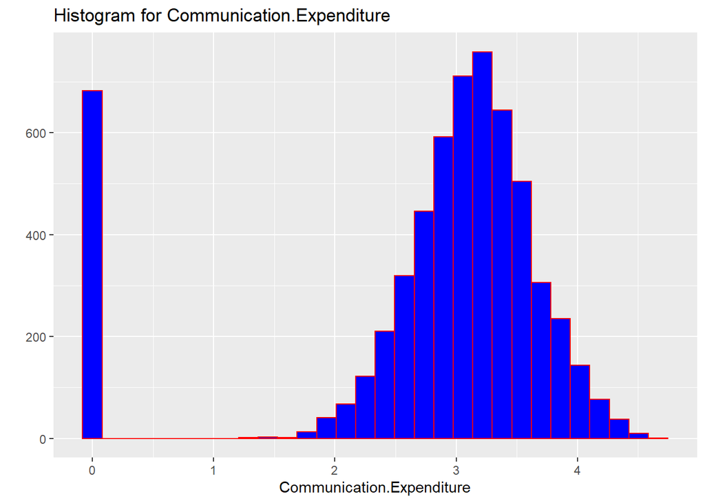

```r
qplot(Log_sin_inf[1:7000,17],
      geom="histogram",
      main = "Histogram for Communication.Expenditure",
      xlab = "Communication.Expenditure",
      fill=I("blue"),
      col=I("red"))
```

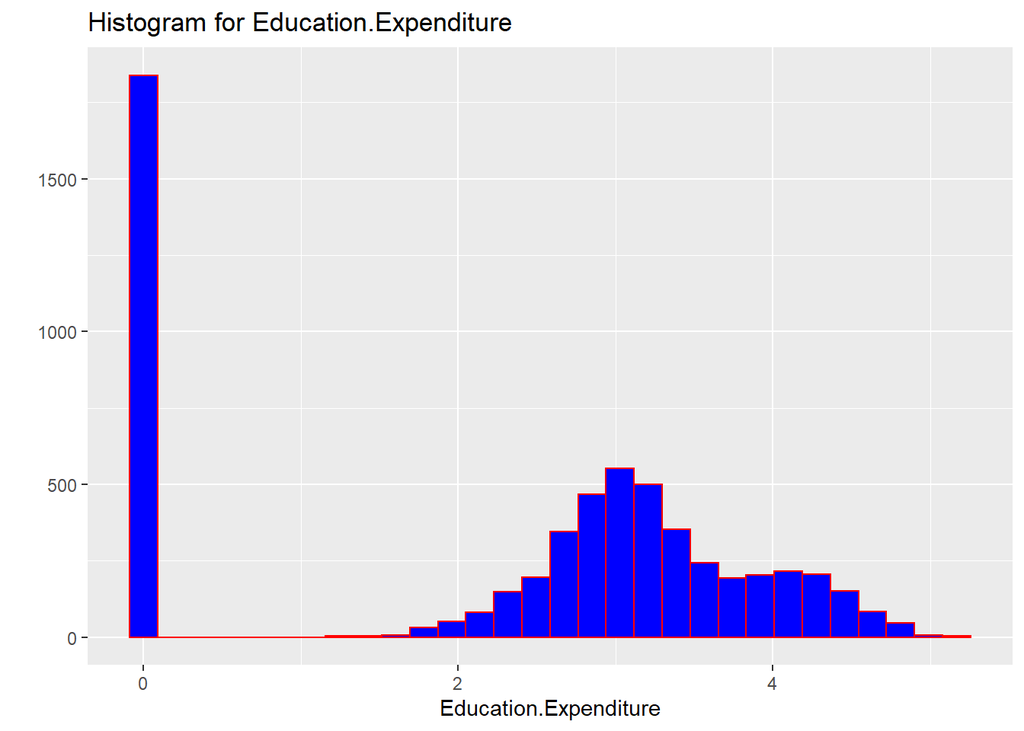

```r
qplot(Log_sin_inf[1:7000,18],
      geom="histogram",
      main = "Histogram for Education.Expenditure",
      xlab = "Education.Expenditure",
      fill=I("blue"),
      col=I("red"))
```

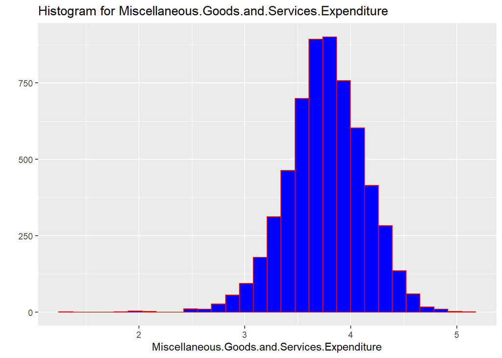

```r
qplot(Log_sin_inf[1:7000,19],
      geom="histogram",
      main = "Histogram for Miscellaneous.Goods.and.Services.Expenditure",
      xlab = "Miscellaneous.Goods.and.Services.Expenditure",
      fill=I("blue"),
      col=I("red"))
```

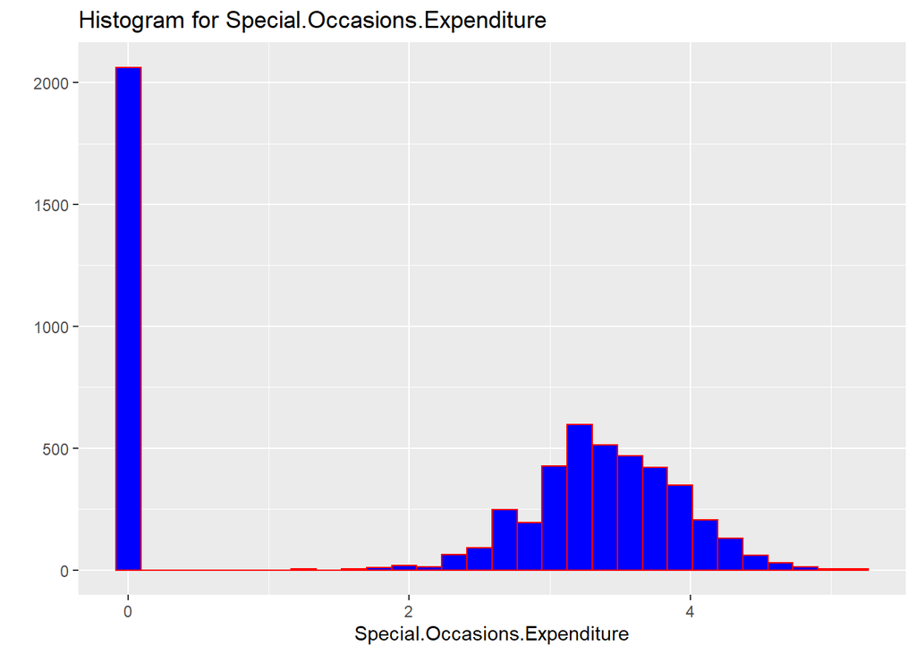

```r
qplot(Log_sin_inf[1:7000,20],
      geom="histogram",
      main = "Histogram for Special.Occasions.Expenditure",
      xlab = "Special.Occasions.Expenditure",
      fill=I("blue"),
      col=I("red"))
```

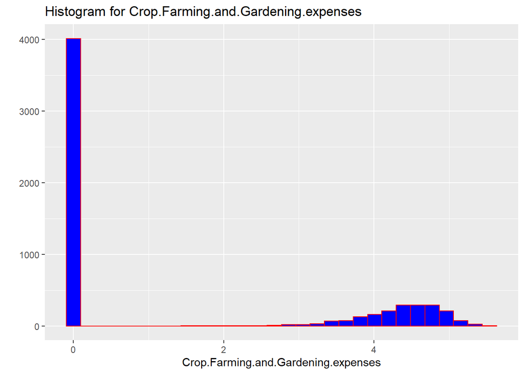

```r
qplot(Log_sin_inf[1:7000,21],
      geom="histogram",
      main = "Histogram for Crop.Farming.and.Gardening.expenses",
      xlab = "Crop.Farming.and.Gardening.expenses",
      fill=I("blue"),
      col=I("red"))
```

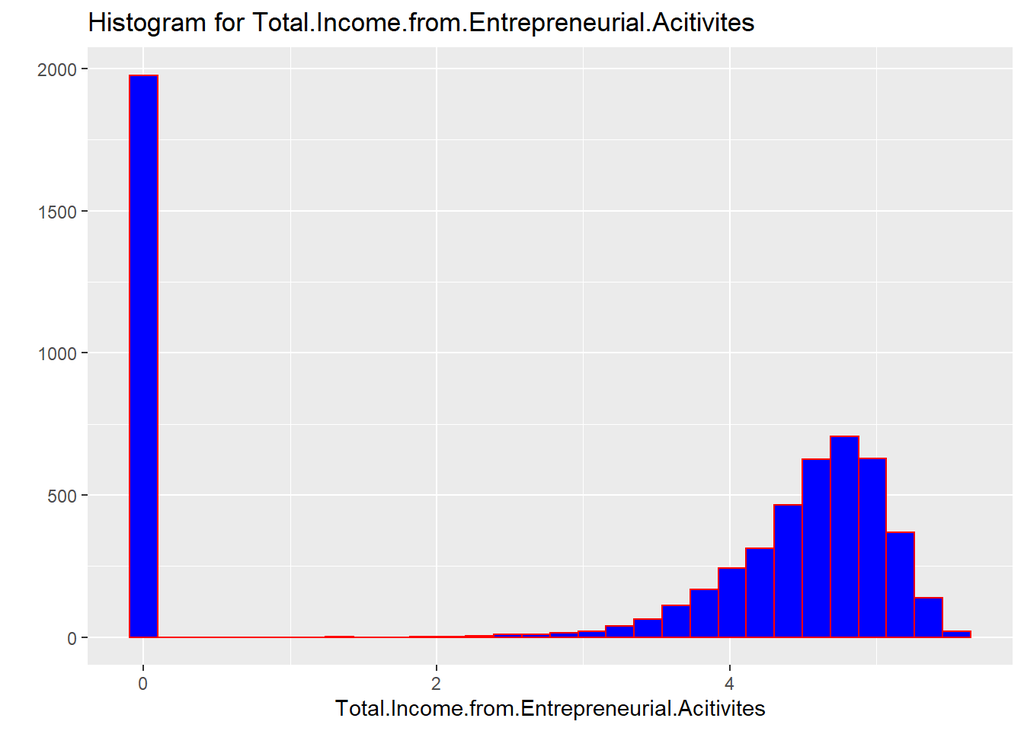

```r
qplot(Log_sin_inf[1:7000,22],
      geom="histogram",
      main = "Histogram for Total.Income.from.Entrepreneurial.Acitivites",
      xlab = "Total.Income.from.Entrepreneurial.Acitivites",
      fill=I("blue"),
      col=I("red"))
```

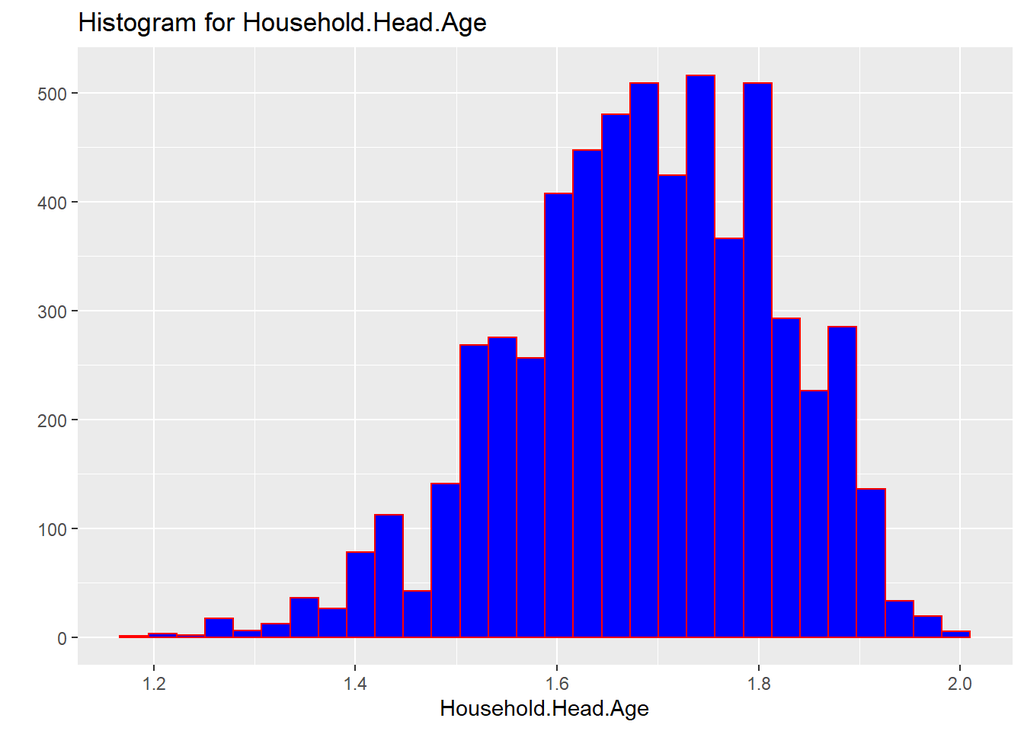

```r
qplot(Log_sin_inf[1:7000,23],
      geom="histogram",
      main = "Histogram for Household.Head.Age",
      xlab = "Household.Head.Age",
      fill=I("blue"),
      col=I("red"))
```

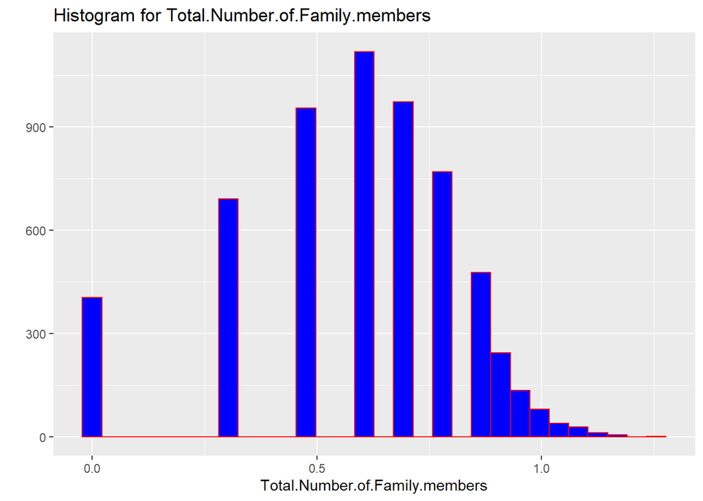

```r
qplot(Log_sin_inf[1:7000,24],
      geom="histogram",
      main = "Histogram for Total.Number.of.Family.members",
      xlab = "Total.Number.of.Family.members",
      fill=I("blue"),
      col=I("red"))
```

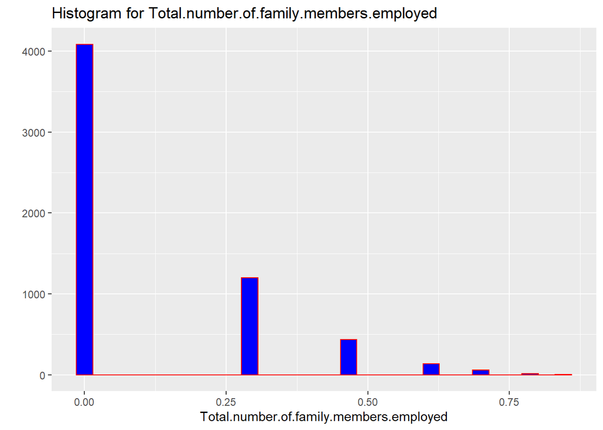

```r
qplot(Log_sin_inf[1:7000,25],
      geom="histogram",
      main = "Histogram for Total.number.of.family.members.employed",
      xlab = "Total.number.of.family.members.employed",
      fill=I("blue"),
      col=I("red"))
```

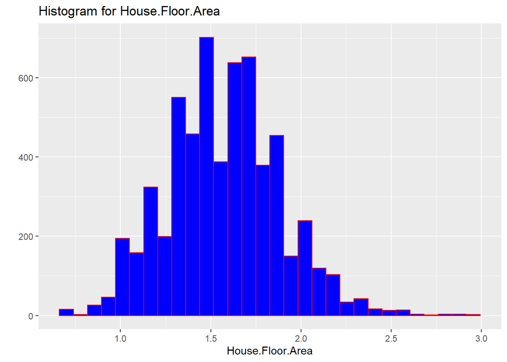

```r
qplot(Log_sin_inf[1:7000,26],
      geom="histogram",
      main = "Histogram for House.Floor.Area",
      xlab = "House.Floor.Area",
      fill=I("blue"),
      col=I("red"))
```

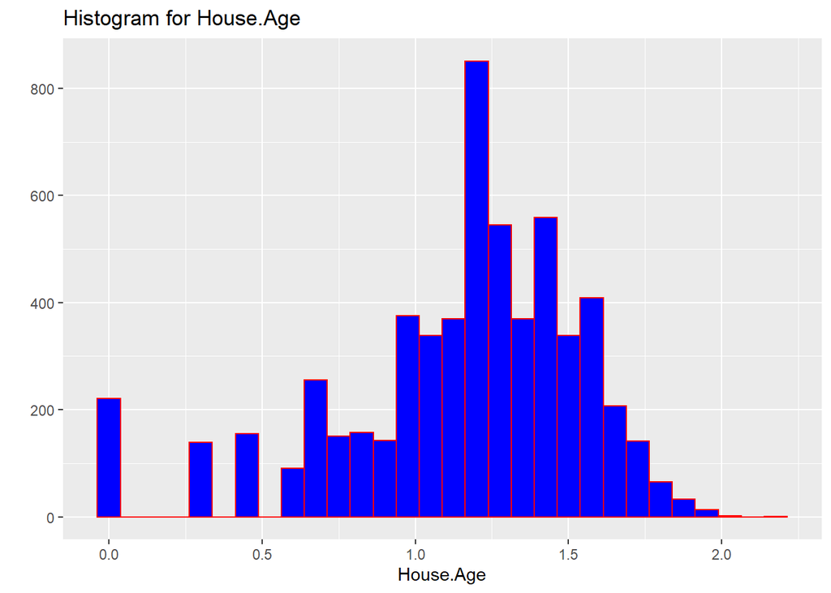

```r
qplot(Log_sin_inf[1:7000,27],
      geom="histogram",
      main = "Histogram for House.Age",
      xlab = "House.Age",
      fill=I("blue"),
      col=I("red"))
```

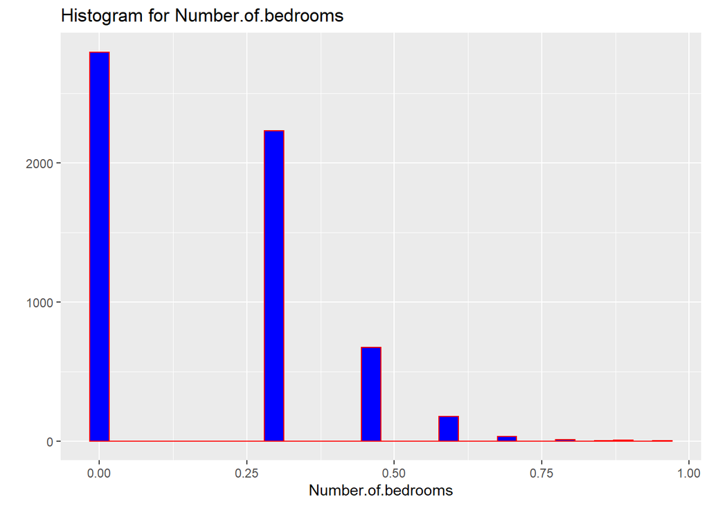

```r
qplot(Log_sin_inf[1:7000,28],
      geom="histogram",
      main = "Histogram for Number.of.bedrooms",
      xlab = "Number.of.bedrooms",
      fill=I("blue"),
      col=I("red"))
```

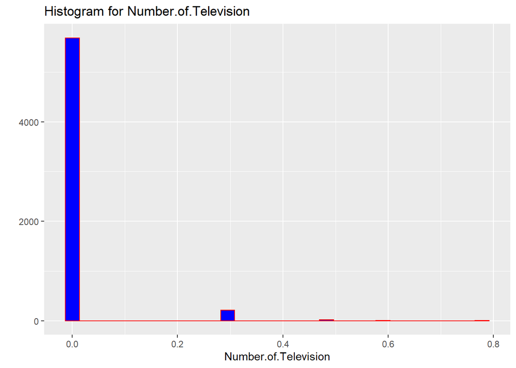

```r
qplot(Log_sin_inf[1:7000,29],
      geom="histogram",
      main = "Histogram for Number.of.Television",
      xlab = "Number.of.Television",
      fill=I("blue"),
      col=I("red"))
```

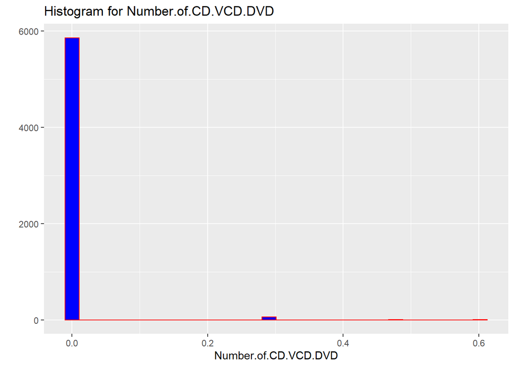

```r
qplot(Log_sin_inf[1:7000,30],
      geom="histogram",
      main = "Histogram for Number.of.CD.VCD.DVD",
      xlab = "Number.of.CD.VCD.DVD",
      fill=I("blue"),
      col=I("red"))
```

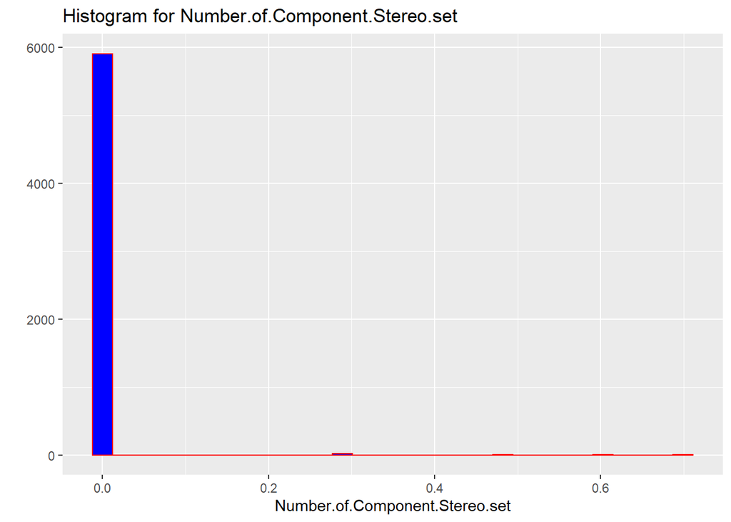

```r
qplot(Log_sin_inf[1:7000,31],
      geom="histogram",
      main = "Histogram for Number.of.Component.Stereo.set",
      xlab = "Number.of.Component.Stereo.set",
      fill=I("blue"),
      col=I("red"))
```

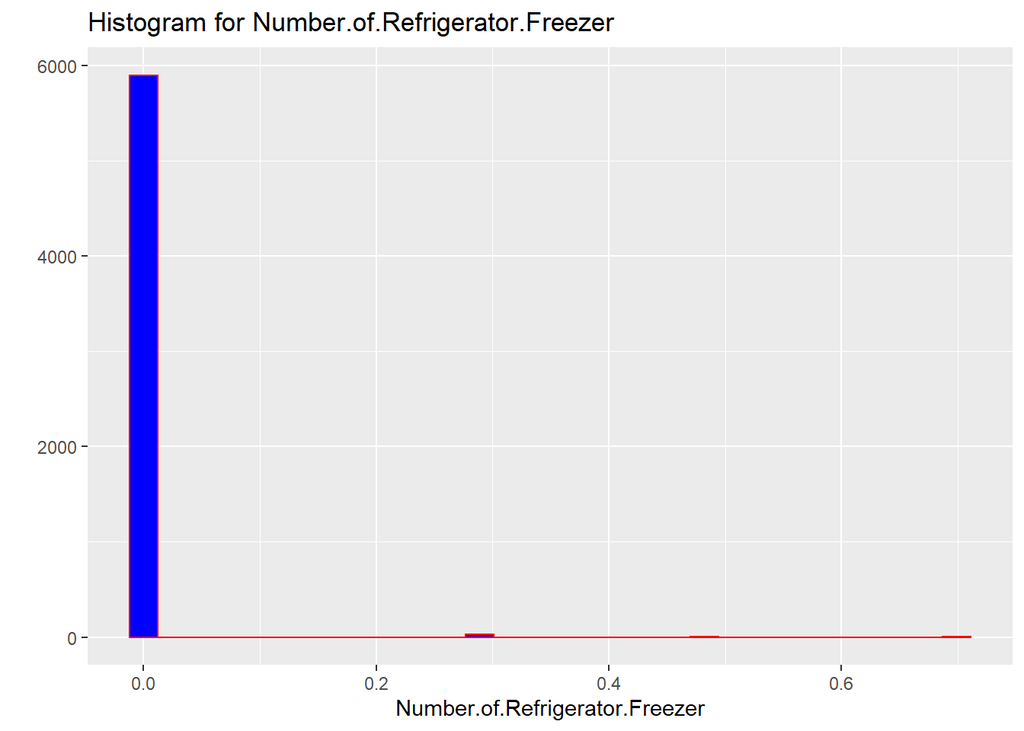

```r
qplot(Log_sin_inf[1:7000,32],
      geom="histogram",
      main = "Histogram for Number.of.Refrigerator.Freezer",
      xlab = "Number.of.Refrigerator.Freezer",
      fill=I("blue"),
      col=I("red"))
```

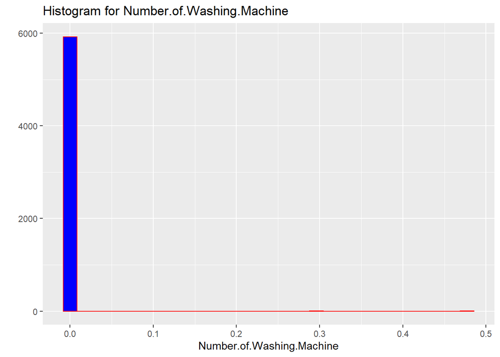

```r
qplot(Log_sin_inf[1:7000,33],
      geom="histogram",
      main = "Histogram for Number.of.Washing.Machine",
      xlab = "Number.of.Washing.Machine",
      fill=I("blue"),
      col=I("red"))
```

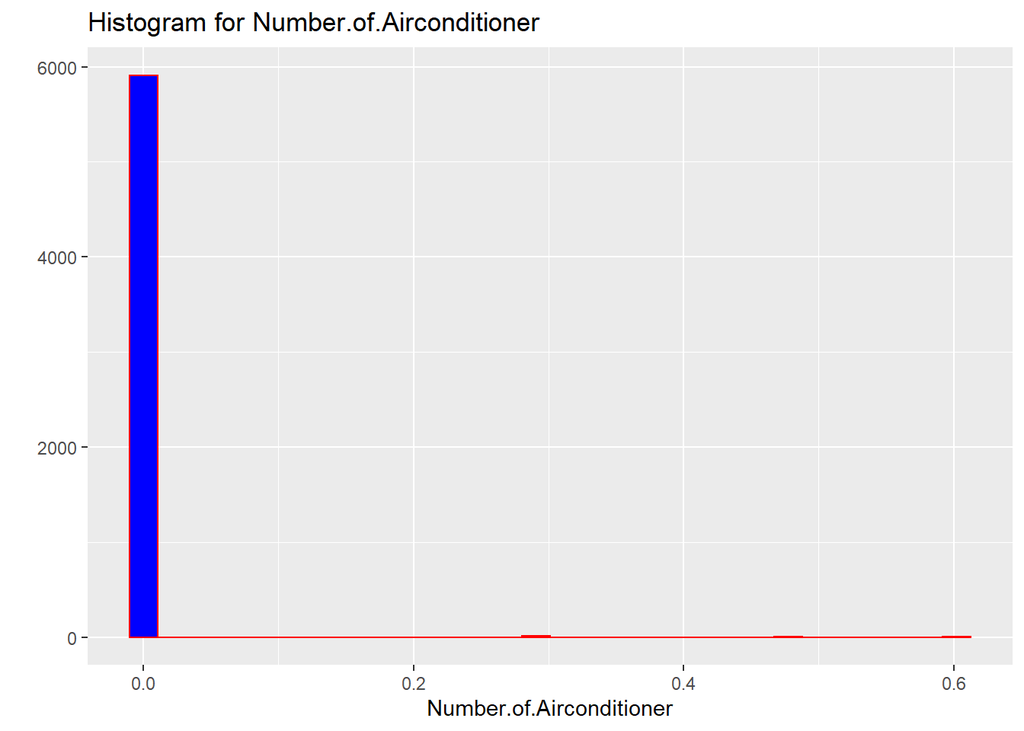

```r
qplot(Log_sin_inf[1:7000,34],
      geom="histogram",
      main = "Histogram for Number.of.Airconditioner",
      xlab = "Number.of.Airconditioner",
      fill=I("blue"),
      col=I("red"))
```

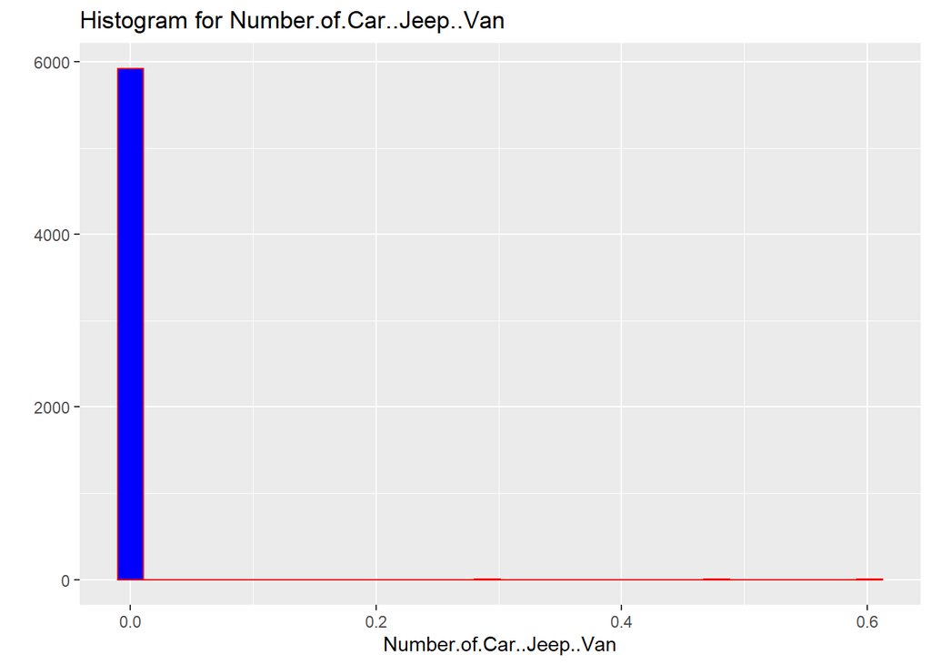

```r
qplot(Log_sin_inf[1:7000,35],
      geom="histogram",
      main = "Histogram for Number.of.Car..Jeep..Van",
      xlab = "Number.of.Car..Jeep..Van",
      fill=I("blue"),
      col=I("red"))
```

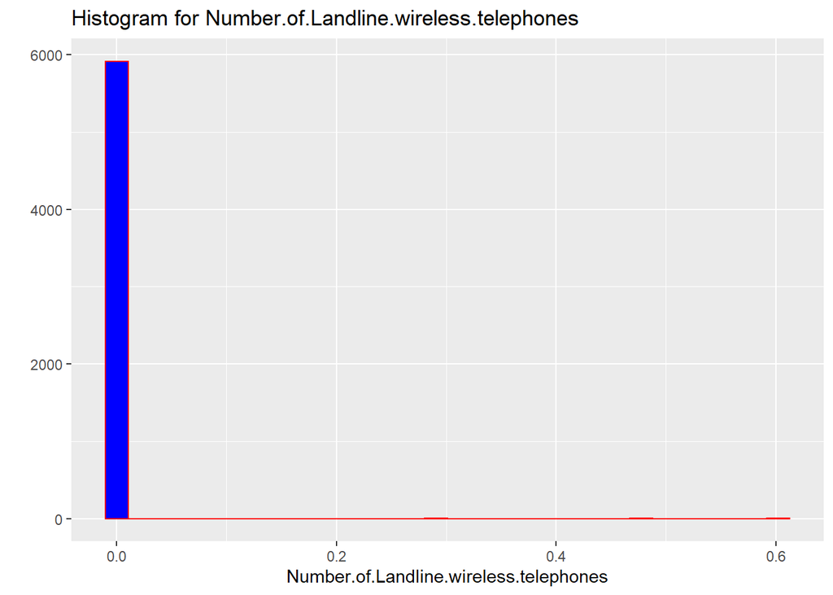

```r
qplot(Log_sin_inf[1:7000,36],
      geom="histogram",
      main = "Histogram for Number.of.Landline.wireless.telephones",
      xlab = "Number.of.Landline.wireless.telephones",
      fill=I("blue"),
      col=I("red"))
```

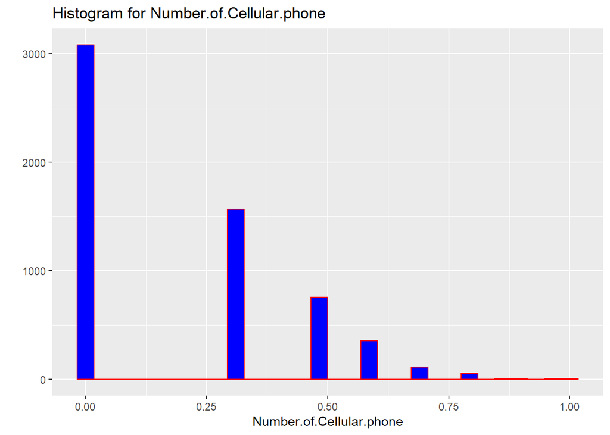

```r
qplot(Log_sin_inf[1:7000,37],
      geom="histogram",
      main = "Histogram for Number.of.Cellular.phone",
      xlab = "Number.of.Cellular.phone",
      fill=I("blue"),
      col=I("red"))
```

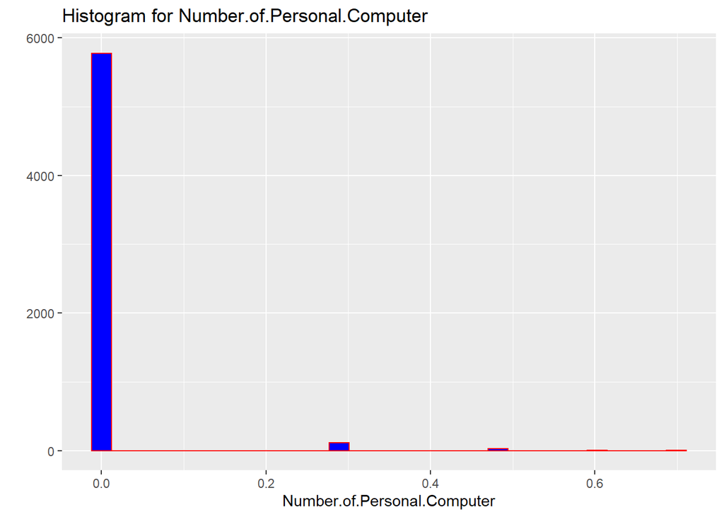

```r
qplot(Log_sin_inf[1:7000,38],
      geom="histogram",
      main = "Histogram for Number.of.Personal.Computer",
      xlab = "Number.of.Personal.Computer",
      fill=I("blue"),
      col=I("red"))
```

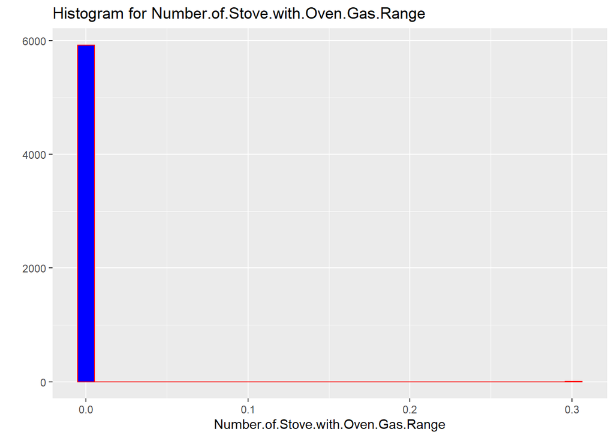

```r
qplot(Log_sin_inf[1:7000,39],
      geom="histogram",
      main = "Histogram for Number.of.Stove.with.Oven.Gas.Range",
      xlab = "Number.of.Stove.with.Oven.Gas.Range",
      fill=I("blue"),
      col=I("red"))
```

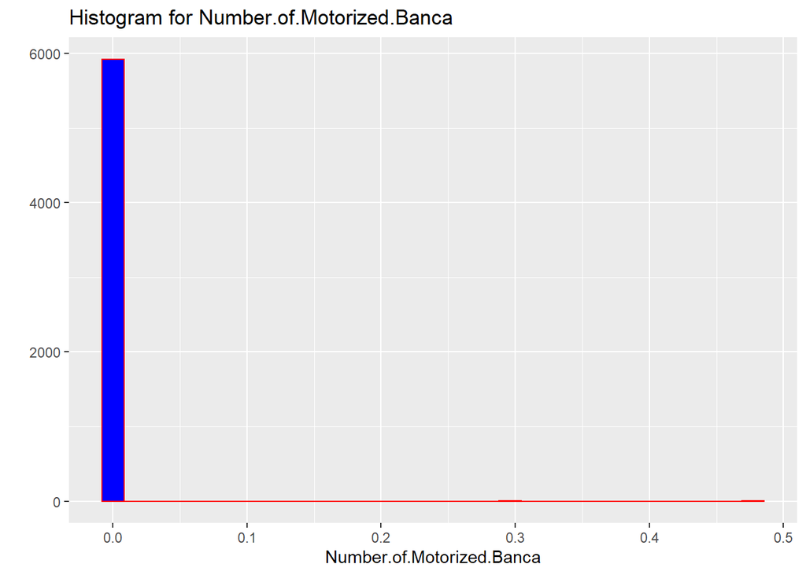

```r
qplot(Log_sin_inf[1:7000,40],
      geom="histogram",
      main = "Histogram for Number.of.Motorized.Banca",
      xlab = "Number.of.Motorized.Banca",
      fill=I("blue"),
      col=I("red"))
```

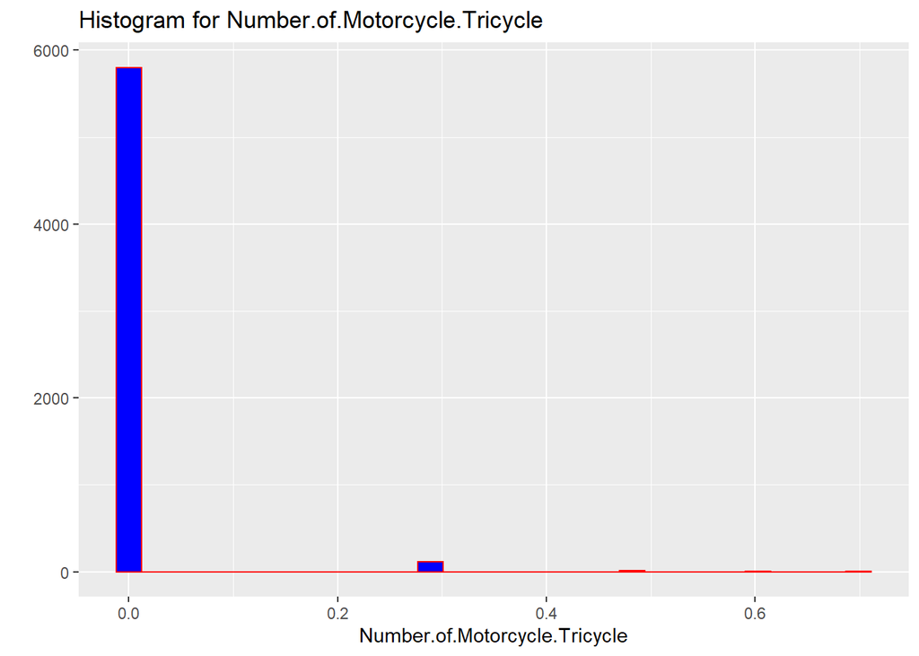

```r
qplot(Log_sin_inf[1:7000,41],
      geom="histogram",
      main = "Histogram for Number.of.Motorcycle.Tricycle",
      xlab = "Number.of.Motorcycle.Tricycle",
      fill=I("blue"),
      col=I("red"))
```

Con esta transformación, se consiguen buenos resultados en general. Muchas variables adquieren distribuciones normales o casi normales, lo que permitirá poder utilizarlas en el diseño del modelo. Sin embargo, hay otras que supondrían un problema, pues tienen distribuciones muy asimétricas.

Algunas variables presentan un porcentaje muy alto de valores iguales a 0, lo que produce un polo en el extremo izquierdo de la distribución. Esto es debido a que la población filipina cuenta con un gran número de familias que viven en condiciones extremas de pobreza (aunque desde 2018, su situación económica está mejorando considerablemente).

En el siguiente apartado, se tendrá en cuenta lo analizado, para descartar aquellas variables cuya distribución no encaje con los requisitos, y partiendo del conjunto de datos transformados logarítmicamente.

## 6. Análisis de correlación

Recordamos las condiciones óptimas de cualquier modelo de regresión lineal múltiple:

- Las variables tienen que tener distribución normal y ser simétricas
- Las variables no pueden estar altamente correlacionadas entre sí

Por lo tanto, y a la vista del apartado anterior, se partirá del conjunto de variables transformadas logarítmicamente. Además, serán descartadas aquellas variables con distribuciones claramente asimétricas. Después, mediante un análisis de la correlación entre pares de las variables matrices, se rechazarán las variables altamente correladas entre sí a la hora de diseñar el modelo de regresión lineal múltiple.

```r
# ----- Descarte de variables que no tienen distribuciones normales/simétricas -----
#-Imputed.House.Rental.Value,
#-Restaurant.and.hotels.Expenditure,
Log_reduced <- Log_sin_inf%>%select(
-Imputed.House.Rental.Value,
-Alcoholic.Beverages.Expenditure,
-Tobacco.Expenditure,
-Restaurant.and.hotels.Expenditure,
-Medical.Care.Expenditure,
-Communication.Expenditure,
-Education.Expenditure,
-Total.number.of.family.members.employed,
-Special.Occasions.Expenditure,
-Crop.Farming.and.Gardening.expenses,
-Total.Income.from.Entrepreneurial.Acitivites,
-Number.of.bedrooms,
-Number.of.Television,
-Number.of.CD.VCD.DVD,
-Number.of.Component.Stereo.set,
-Number.of.Refrigerator.Freezer,
-Number.of.Washing.Machine,
-Number.of.Airconditioner,
-Number.of.Car..Jeep..Van,
-Number.of.Landline.wireless.telephones,
-Number.of.Cellular.phone,
-Number.of.Personal.Computer,
-Number.of.Stove.with.Oven.Gas.Range,
-Number.of.Motorized.Banca,
-Number.of.Motorcycle.Tricycle)

# Cálculo de la matriz de correlaciones cruzadas

cor_matrix_log_reduced <- round(cor(Log_reduced),4)
```

Una vez seleccionadas solo aquellas variables que tienen distribuciones simétricas, se procede a mostrar un mapa de calor de la matriz de correlaciones cruzadas:

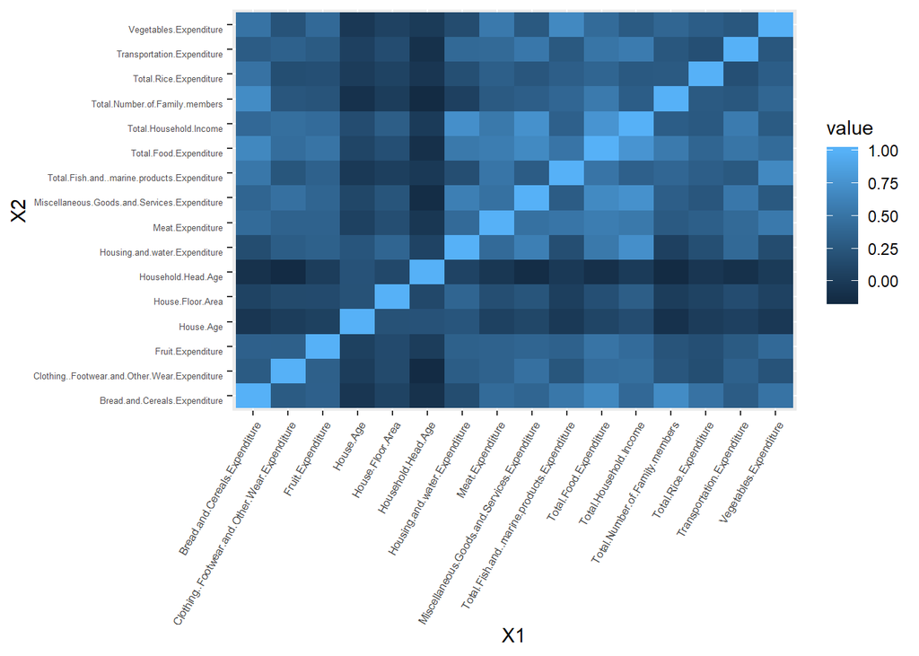

```r
#----- Mapa de calor de la matriz de correlaciones cruzadas----------

mapa_corr <- melt(cor_matrix_log_reduced)
ggplot(data = mapa_corr, aes(x =X1, y =X2, fill =value)) + geom_tile() + theme(axis.text.x = element_text(angle = 60, vjust= 1, size = 6, hjust = 1)) + theme(axis.text.y = element_text( vjust= 1, size = 5, hjust = 1))
```

## 7. Selección de variables y modelo

Es conveniente evitar variables altamente correlacionadas entre sí, descartando de cada par la que más correlada esté con todas las demás. En el análisis no se incluirá la variable a predecir (“Total.Household.Income”).

Se aplica un umbral de valor absoluto igual a 0.5, para filtar aquellas variables correladas entre sí por encima de él.

```r
# ----- Selección de variables ----- #

# Subconjunto sin la variable "income" a predecir

sin_income_log <- Log_reduced[,c(2:length(Log_reduced))]

# Descarte de variables altamente correlacionadas (findCorrelation)

index_log<-findCorrelation(cor(sin_income_log),cutoff =.5,verbose = TRUE,exact = TRUE)
```

```
## Compare row 1  and column  11 with corr  0.687
##   Means:  0.446 vs 0.271 so flagging column 1
## Compare row 11  and column  10 with corr  0.539
##   Means:  0.347 vs 0.249 so flagging column 11
## Compare row 2  and column  5 with corr  0.535
##   Means:  0.332 vs 0.23 so flagging column 2
## Compare row 4  and column  5 with corr  0.52
##   Means:  0.321 vs 0.212 so flagging column 4
## Compare row 5  and column  7 with corr  0.683
##   Means:  0.253 vs 0.191 so flagging column 5
## All correlations <= 0.5
```

```r
sin_income_log <- sin_income_log%>%select(-index_log)


# Con el nuevo conjunto de variables, se calcula la matriz de correlación

new_var_train_log<-cbind(Total.Household.Income=Log_reduced[,1],sin_income_log)

cor_mat_log<-cor(new_var_train_log)

cor_mat_log<-cor_mat_log[,order(cor_mat_log[1,],decreasing = T)]
```

Mapa de calor tras descartar ciertas variables:

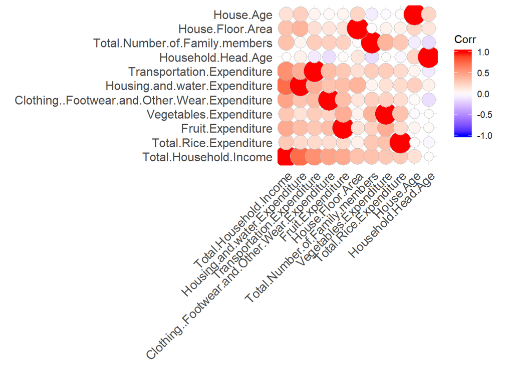

```r
ggcorrplot(t(cor_mat_log), method = "circle") # Representación gráfica del mapa de calor
```

```r
# Se escogerán las que tengan una correlación > de 0.5 con respecto al "Total.Household.Income"

Variables_ordenadas<-data.frame(t(cor_mat_log)[,'Total.Household.Income']) # Es para quedarse con la columna ordenada
colnames(Variables_ordenadas)<-'Coef. Corr'
View(Variables_ordenadas)
```

## 8. Ajuste, interpretación y diagnosis del modelo de regresión lineal múltiple

Se realiza la regresión lineal múltiple con las variables cuyo valor de correlación con el Income es superior a 0.4. Después, se calculan los residuos, los valores ajustados, y se visualizan:

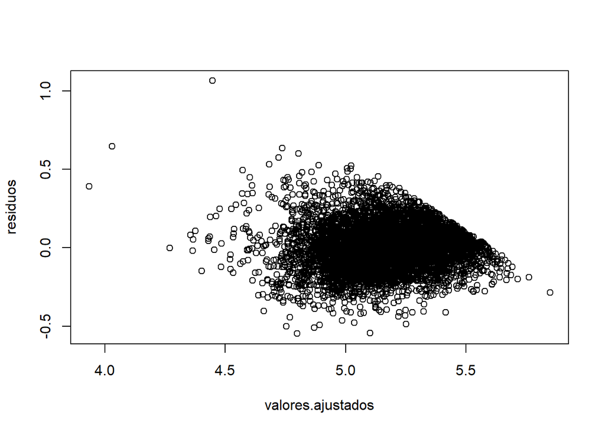

```r
# Se realiza la regresión lineal múltiple con las variables cuyo valor de correlación con el Income es superior a 0.4
RLM<-lm(Total.Household.Income~Housing.and.water.Expenditure
          +Transportation.Expenditure
          +Clothing..Footwear.and.Other.Wear.Expenditure
          +Fruit.Expenditure
          ,data=new_var_train_log)


# Cálculo de residuos del modelo

residuos <-(residuals(RLM))

# Calculo de los valores ajustados con las observaciones de entrenamiento

valores.ajustados <- (fitted(RLM))

# Verificación de la no relación lineal entre valores predichos y  residuos

plot(valores.ajustados, residuos,col="black")
```

# Resumen del modelo diseñado:

```r
# Valores de los betas estimados en la regresión lineal múltiple

summary(RLM)
```

```
##
## Call:
## lm(formula = Total.Household.Income ~ Housing.and.water.Expenditure +
##     Transportation.Expenditure + Clothing..Footwear.and.Other.Wear.Expenditure +
##     Fruit.Expenditure, data = new_var_train_log)
##
## Residuals:
##      Min       1Q   Median       3Q      Max
## -0.54742 -0.09141 -0.00512  0.08714  1.06368
##
## Coefficients:
##                                               Estimate Std. Error t value
## (Intercept)                                   2.488967   0.026375   94.37
## Housing.and.water.Expenditure                 0.417984   0.006774   61.70
## Transportation.Expenditure                    0.104066   0.003592   28.97
## Clothing..Footwear.and.Other.Wear.Expenditure 0.072035   0.003622   19.89
## Fruit.Expenditure                             0.078366   0.005266   14.88
##                                                          Pr(>|t|)
## (Intercept)                                   <0.0000000000000002 ***
## Housing.and.water.Expenditure                 <0.0000000000000002 ***
## Transportation.Expenditure                    <0.0000000000000002 ***
## Clothing..Footwear.and.Other.Wear.Expenditure <0.0000000000000002 ***
## Fruit.Expenditure                             <0.0000000000000002 ***
## ---
## Signif. codes:  0 '***' 0.001 '**' 0.01 '*' 0.05 '.' 0.1 ' ' 1
##
## Residual standard error: 0.1437 on 5925 degrees of freedom
## Multiple R-squared:  0.665,  Adjusted R-squared:  0.6647
## F-statistic:  2940 on 4 and 5925 DF,  p-value: < 0.00000000000000022
```

Para comprobar que el resultado es correcto, se observa en la próxima gráfica si los residuos siguen una distribución normal. Para ello, se representa el gráfico Q-Q que compara los cuantiles teóricos de una normal con los calculados. Cuantos más puntos caigan en la recta, mejor. Además, se realiza un test de normalidad con las siguientes hipótesis:

- H0: los datos proceden de una distribución normal
- H1: los datos no proceden de una distribución normal

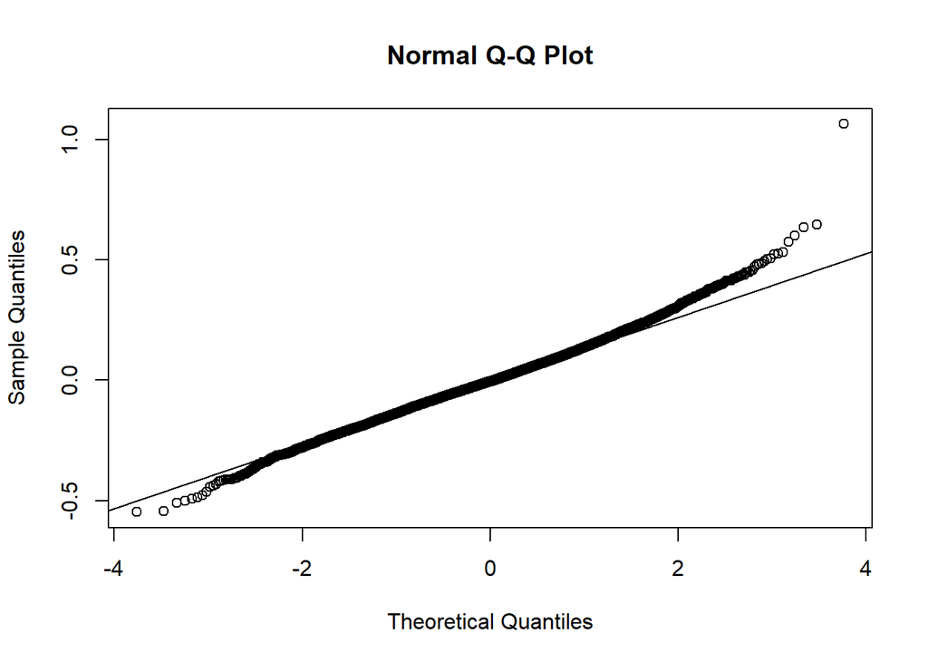

```r
qqnorm(residuos)

qqline(residuos)
```

```r
ks.test(residuos,pnorm,mean=mean(residuos),sd=sd(residuos))
```

```
##
##  One-sample Kolmogorov-Smirnov test
##
## data:  residuos
## D = 0.023329, p-value = 0.003146
## alternative hypothesis: two-sided
```

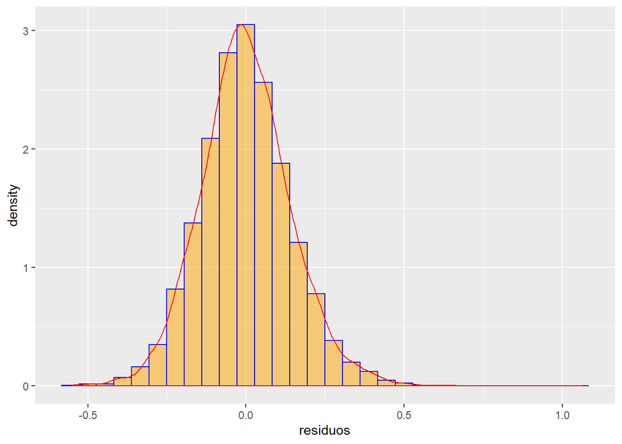

```r
residuos<-as.data.frame(residuos)
ggplot(residuos, aes(x=residuos)) +
 geom_histogram(color='blue',fill='orange',aes(y=..density..), alpha=0.5,
                position="identity")+
 geom_density(color='red',alpha=.2)
```

```r
residuos%>%summarise(media=mean(residuos),
                            max=max(residuos),
                            min=min(residuos),
                            sd=sd(residuos),
                            var=var(residuos))
```

| media | max | min | sd | var |
| --- | --- | --- | --- | --- |
| 0.000000000000000007157168 | 1.063684 | -0.5474236 | 0.1436438 | 0.02063353 |

# Validación del modelo

Utilizando el conjunto de test (30% de las observaciones) separado al principio, se evaluará el modelo, para ver sus prestaciones a la hora de calcular los ingresos.

Visualizamos los residuos obtenidos:

```r
# Del conjunto de test, se seleccionan las variables adecuadas

pre_datos_testing_original <- datos_testing %>% filter(Total.Household.Income < 400000)


pre_datos_testing <- pre_datos_testing_original%>%select(Housing.and.water.Expenditure,
                                                Transportation.Expenditure
          ,Clothing..Footwear.and.Other.Wear.Expenditure
        ,Fruit.Expenditure)


# Es necesario transformar logarítmicamente el conjunto de test antes de usarlo para validar, pues el conjunto de train estaba transformado logarítmicamente

pre_datos_testing<-log10(pre_datos_testing)


# Quitamos los valores -Inf transformandolos a 0

pre_datos_testing <- replace(pre_datos_testing,pre_datos_testing=="-Inf",0)


# Predicción con el modelo de RLM calculado

predichos_log <- predict(RLM,pre_datos_testing)

# Calculo de los residuos en el dominio transformado (log10)
valores_reales_log<-log10(pre_datos_testing_original$Total.Household.Income)
residuos_log<-valores_reales_log  -predichos_log
```

Es conveniente representar los residuos frente a los valores predichos en el dominio transformado (log10)

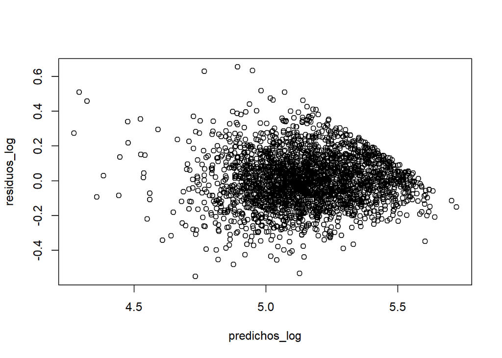

```r
# Es conveniente representar los residuos frente a los valores predichos en el dominio transformado (log10)
plot(predichos_log,residuos_log)
```

Se puede observar que el gráfico no varía mucho con respecto al mismo gráfico representado anteriormente (utilizando el conjunto de training):

```r
df_comp_log10<-data.frame(predichos_log10=predichos_log,Valores_reales_log=valores_reales_log)

# Se obtienen, en un vector, los valores reales para compararlos con los predichos. Para ello, se calculan sus residuos

Valores_reales<-(pre_datos_testing_original$Total.Household.Income)

Valores_predichos<-10^(predichos_log)

# Calculamos los residuos

residuos<-Valores_reales-Valores_predichos
```

Son representados en un gráfico de dispersión los valores predichos por el modelo con los residuos en unidades normales (deshaciendo el logaritmo)

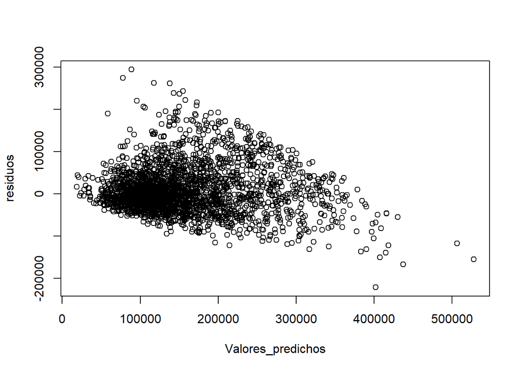

```r
# Representamos en un gráfico de dispersión los valores predichos por el modelo con los residuos en unidades normales (deshaciendo el logaritmo)
plot(Valores_predichos,residuos)
```

Se muestra una comparativa entre los valores predichos y los reales:

```r
#Comprobamos los valores predichos y originales en los dos dataFrames siguientes:
df_com_original<-data.frame(predichos=Valores_predichos,reales=Valores_reales,residuos=residuos)

#Originales
df_com_original
```

|  | predichos | reales | residuos |
| --- | --- | --- | --- |
| 1 | 103559.13 | 185151 | 81591.867614 |
| 2 | 145756.63 | 201470 | 55713.366665 |
| 3 | 208687.52 | 228645 | 19957.480100 |
| 4 | 105565.84 | 144595 | 39029.162049 |
| 5 | 125141.52 | 76894 | -48247.515391 |
| 6 | 198723.92 | 219786 | 21062.080408 |
| 7 | 226159.17 | 223996 | -2163.166667 |
| 8 | 199678.82 | 346997 | 147318.180239 |
| 9 | 144923.61 | 154526 | 9602.385097 |
| 10 | 282935.86 | 274576 | -8359.857777 |

[output cut: 2545 more lines]

```r
#Queremos ver cuanto nos equivocamos viendo los residuos
df_com_original%>%summarise(media=mean(residuos),
                            max=max(residuos),
                            min=min(residuos),
                            sd=sd(residuos),
                            var=var(residuos))
```

| media | max | min | sd | var |
| --- | --- | --- | --- | --- |
| 9055.394 | 294380.7 | -221456 | 55937.6 | 3129014933 |

Se debe tener en cuenta que los valores de ingresos (predichos y reales) están en moneda filipina, y que la equivalencia a euros es: 1 peso filipino –> 0.018 euros.

Para comprobar la normalidad de los residuos, se utiliza el gráfico Q-Q que compara los cuantiles teóricos de una normal con los calculados. Cuantos más puntos caigan en la recta, mejor.

Llegados hasta este punto, resulta interesante mostrar el gráfico Q-Q, histograma y test de normalidad para los residuos.

- Datos transformados logarítmicamente:

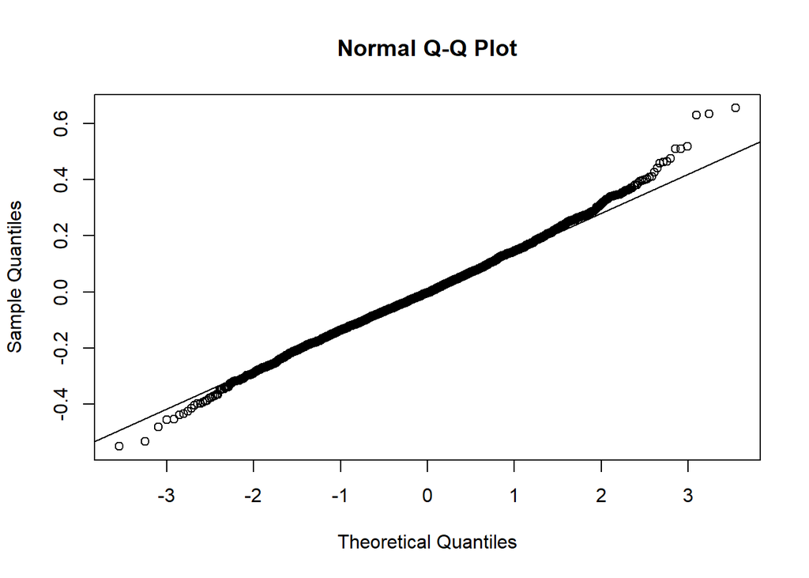

```r
# Unidades logarítmicas
qqnorm(residuos_log)
qqline(residuos_log)
```

```r
ks.test(residuos_log,pnorm,mean=mean(residuos_log),sd=sd(residuos_log))
```

```
##
##  One-sample Kolmogorov-Smirnov test
##
## data:  residuos_log
## D = 0.02115, p-value = 0.2031
## alternative hypothesis: two-sided
```

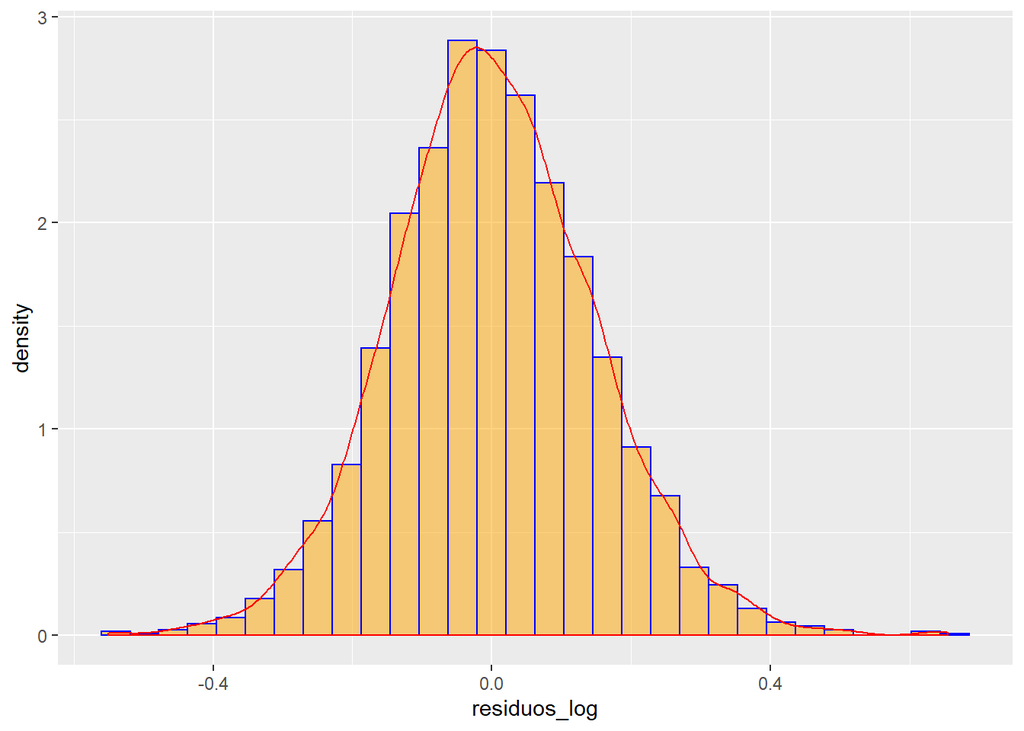

```r
residuos_log<-as.data.frame(residuos_log)
ggplot(residuos_log, aes(x=residuos_log)) +
 geom_histogram(color='blue',fill='orange',aes(y=..density..), alpha=0.5,
                position="identity")+
 geom_density(color='red',alpha=.2)
```

```r
residuos_log%>%summarise(media=mean(residuos_log),
                            max=max(residuos_log),
                            min=min(residuos_log),
                            sd=sd(residuos_log),
                            var=var(residuos_log))
```

| media | max | min | sd | var |
| --- | --- | --- | --- | --- |
| 0.002575102 | 0.6544821 | -0.5500986 | 0.1473201 | 0.02170321 |

- Datos sin transformar (en su escala original)

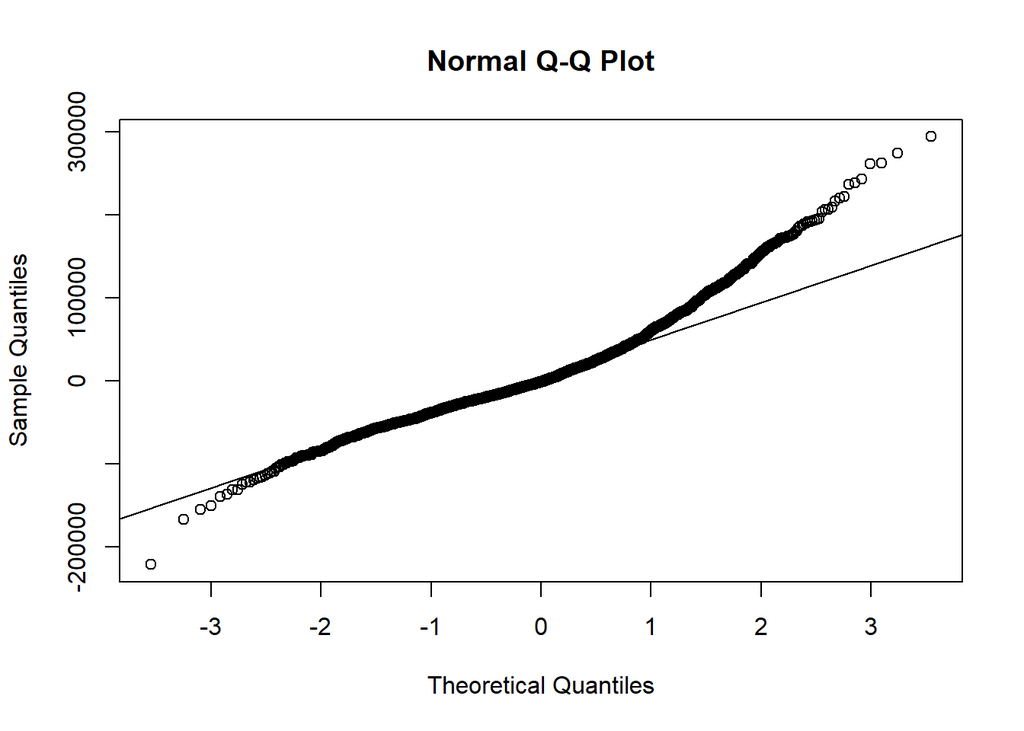

```r
# Unidades normales
qqnorm(residuos)
qqline(residuos)
```

```r
ks.test(residuos,pnorm,mean=mean(residuos),sd=sd(residuos))
```

```
##
##  One-sample Kolmogorov-Smirnov test
##
## data:  residuos
## D = 0.08753, p-value < 0.00000000000000022
## alternative hypothesis: two-sided
```

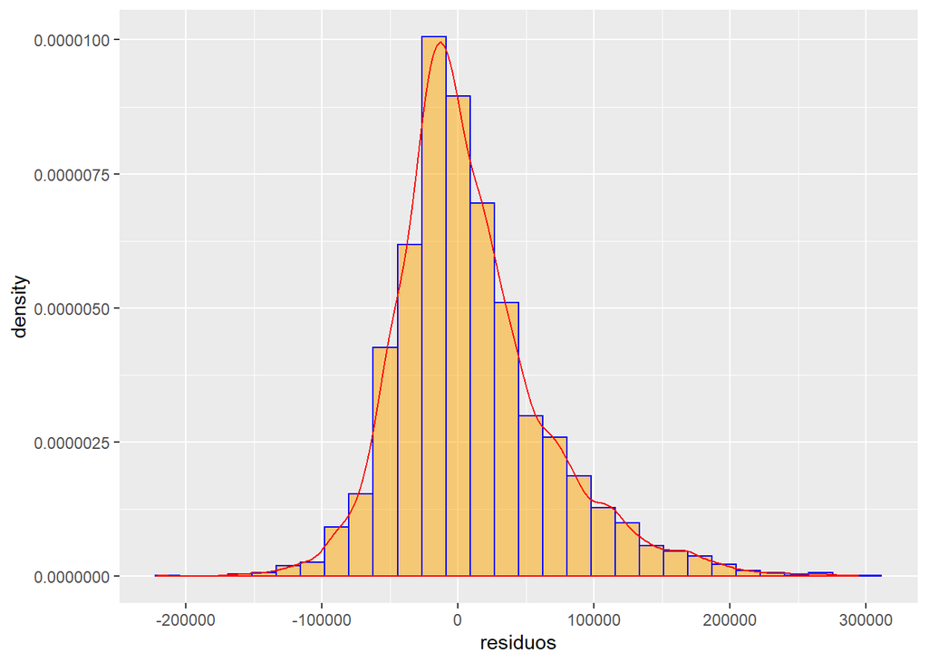

```r
residuos<-as.data.frame(residuos)
ggplot(residuos, aes(x=residuos)) +
 geom_histogram(color='blue',fill='orange',aes(y=..density..), alpha=0.5,
                position="identity")+
 geom_density(color='red',alpha=.2)
```

```r
residuos%>%summarise(media=mean(residuos),
                            max=max(residuos),
                            min=min(residuos),
                            sd=sd(residuos),
                            var=var(residuos))
```

| media | max | min | sd | var |
| --- | --- | --- | --- | --- |
| 9055.394 | 294380.7 | -221456 | 55937.6 | 3129014933 |

## Conclusiones

A lo largo del análisis, han sido descubiertas cosas interesantes que han sido de gran ayuda a la hora de definir un modelo de regresión lineal adecuado a los datos:

- La población filipina es una *población generalmente pobre*, y con muchas desigualdades. Esto conduce a encontrarse con muchos valores atípicos (familias más ricas) y problemas para definir un modelo integrando todos los elementos del data set.
- Existen *dos o más comportamientos diferentes* dentro del data set. Esto significa que, para desarrollar un modelo lógico que sea capaz de predecir los ingresos de una familia, deberemos diferenciar entre la familia filipina común (equivalente al 85% y mayoritariamente pobre) y la familia filipina de clase alta (aquellas que suponen valores atípicos y no son representativas de la situación económica más extendida).
- Al analizar una población con tanto nivel de pobreza, debemos entender que hay variables predictoras de los ingresos que en otras sociedades con menor desigualdad y menor escasez económica, si podrían tener significancia, pero en este tipo de datos no la tienen. Por ejemplo, variables como los gastos en ropa, en comunicación, o en bienes de lujo, cuentan con un alto porcentaje de ceros (0). El problema radica en entender que para este tipo de poblaciones, las cuales no gastan practicamente nada fuera de primera necesidad, existen otras variables más adecuadas para predecir los ingresos.

La población filipina debe tratarse como una población pobre, con variables predictoras del nivel de ingresos algo diferentes a otro tipo de población con menores desigualdades, o en todo caso más “lineales”: niveles de ingresos más repartidos entre clases (que exista clase baja, media-baja, media, media alta y alta).